# How do changes in ex vary between countries?

Jon Minton, Lucinda Hiam

22/02/2022

# To dos

- Create flextable by decade

# Introduction

Stalling of life expectancy improvements occurred in the UK from 2010 onwards. It was also seen in some other Western European countries. While the reason and severity of this is debated, some also contend the stalling of improvements seen is artefact following an unusual decade of improvement in 2000s (e.g. Murphy 2021).

- Introduction to be written once methods/results discussed and decided on

# Methods

## Data

Data were extracted from the [Human Mortality Database](https://mortality.org/) via the R package [`HMDHFDplus`](http://www.demogr.mpg.de/en/projects_publications/publications_1904/mpidr_technical_reports/reading_human_fertility_database_and_human_mortality_database_data_into_r_5438.htm).

The following countries are included in the comparison:

- England & Wales (`GBRTENW`)
- Scotland (`GBR_SCO`)
- UK as a whole (`GBR_UK`) #we haven’t included UK but can do
- France (`FRANTP`)
- Spain (`ESP`)
- Italy (`ITA`)
- Germany
  - Total Germany (`DEUTNP`)
  - East Germany (`DEUTE`)
  - West Germany (`DEUTW`)
  - Simulated/Synthetic Germany

## Analysis

For each of these countries, and for males and females separately, we are interested in the annual changes in life expectancy at birth ($e_0$) and life expectancy at age 65 ($e_{65}$), from 1980 to the last available year for each country. In addition, we compare average life expectancy improvements over the 4 decades: 1980, 1990, 2000, and 2010.

We then compared whether the average between the decades was significant, using a regression model.

### Synthetic Germany

- To maybe be moved to the appendix later

```
## # A tibble: 3,820 x 5
##    code    year     x sex       ex
##    <chr>  <int> <int> <chr>  <dbl>
##  1 DEUTNP  1990     0 female  78.4
##  2 DEUTNP  1990    65 female  17.6
##  3 DEUTNP  1991     0 female  78.7
##  4 DEUTNP  1991    65 female  17.8
##  5 DEUTNP  1992     0 female  79.1
##  6 DEUTNP  1992    65 female  18.1
##  7 DEUTNP  1993     0 female  79.2
##  8 DEUTNP  1993    65 female  18.1
##  9 DEUTNP  1994     0 female  79.5
## 10 DEUTNP  1994    65 female  18.4
## # ... with 3,810 more rows
```

# Results

## Descriptive Results

### Life expectancy trends

The following figures show life expectancy at birth and at age 65 for selected nations from 1980 to the latest available year for males and females.

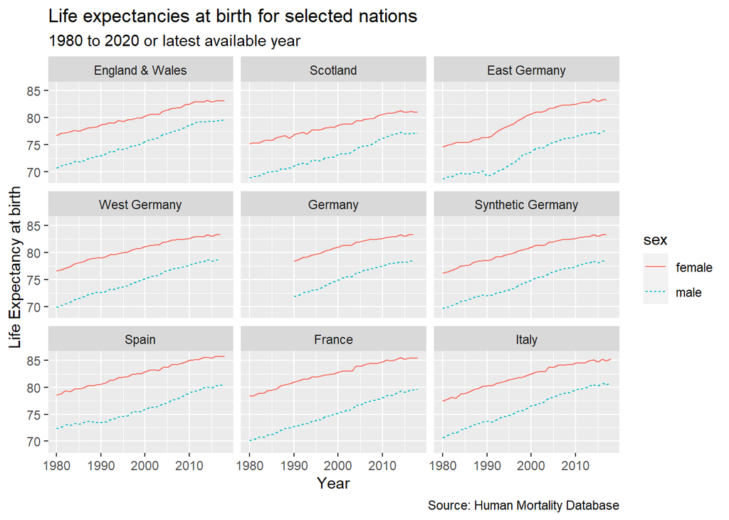

Life Expectancy at birth

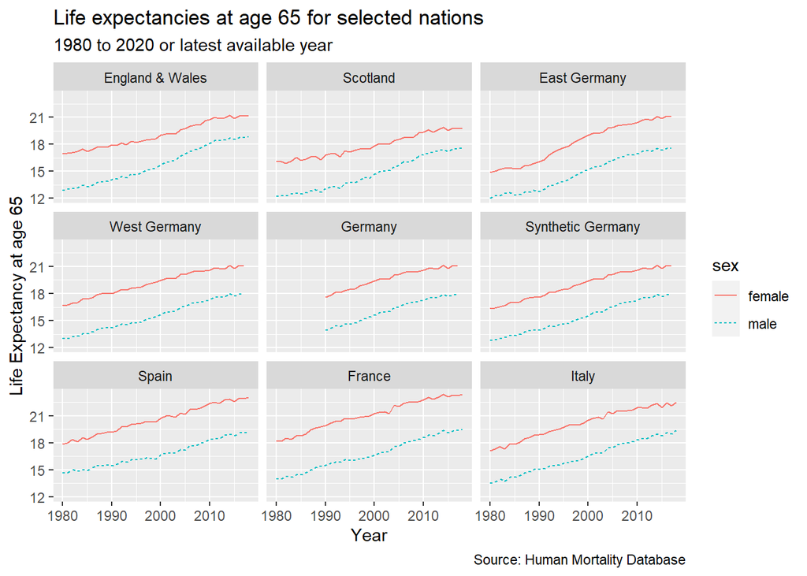

Life Expectancy at age 65

- Some insightful comment about what’s going on.

## Change in life expectancy in these nations

Next, we compare the annual change in life expectancy at birth and at aged 65 years for the nations from 1980 to the latest available year, by sex.

```
## # A tibble: 3,972 x 6
##    code    year     x sex       ex delta_ex
##    <chr>  <int> <dbl> <chr>  <dbl>    <dbl>
##  1 FRATNP  1816     0 female  41.1  NA
##  2 FRATNP  1816    65 female  10.8  NA
##  3 FRATNP  1816     0 male    39.1  NA
##  4 FRATNP  1816    65 male    10.7  NA
##  5 FRATNP  1817     0 female  40.2  -0.890
##  6 FRATNP  1817    65 female  11.0   0.210
##  7 FRATNP  1817     0 male    38.2  -0.830
##  8 FRATNP  1817    65 male    10.6  -0.140
##  9 FRATNP  1818     0 female  39.1  -1.13
## 10 FRATNP  1818    65 female  11.1   0.0300
## # ... with 3,962 more rows
```

### Changes in life expectancy at birth

- make smoother lines coloured by sex
- use consistent colours for all graphs showing separate sex results

[figure not shown]

### Changes in life expectancy at age 65

- Use slightly stronger (and consistent) colours for sex smoother lines

[figure not shown]

## Time trends

- Give this a title and further info (lower priority)
- Look at splitting by starting age
  - Look at further refining starting age split

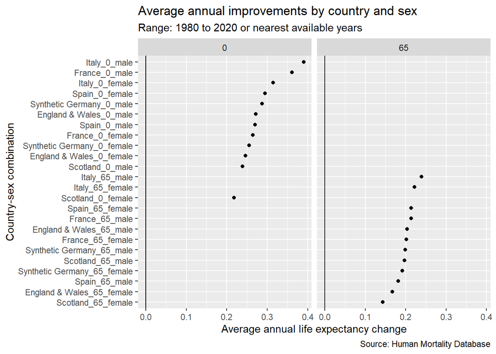

### Average improvements by decade

- Add further introduction
- Add statistical significance (though maybe this is a different analysis)

Average improvement in life expectancy by decade

| sex | 1980 | 1990 | 2000 | 2010 |
| --- | --- | --- | --- | --- |
| female | 0.19 (0.177) | 0.164 (0.215) | 0.248 (0.211) | 0.083 (0.184) |
| male | 0.252 (0.159) | 0.231 (0.193) | 0.315 (0.148) | 0.137 (0.187) |

### Are the differences by decade statistically significant?

Are there significant differences in average rates of change in $e_x$ by decade? Another way of expressing this question is to ask whether knowing the decade in which an observation has been observed is informative as to what such values will be. This rephrased question was addressed by, for each starting age (0 or 65 years), sex and country, fitting two competing model specifications - $M_0$ and $M_A$ - and running an F test on the residuals of these two models. The Null model specification, $M_0$, regresses $\delta e_x$ (observed annual changes in $e_x$) against a single intercept term $\alpha$; put another way: $M_0$ assumes that all observations are drawn from a Normal distribution with a mean value of $\alpha$, and that this is consistent across all observed decades. The alternative model specification, $M_A$, also includes the $\alpha$ term, but also includes dummy variables to indicate which decade the realised value of $\delta e_0$ corresponds to. (Because one of the decades needs to be the reference category against which other decades are compared, there are one fewer decadal dummy variables than decades in the dataset for a given country, and the $\alpha$ parameter in $M_A$ estimates the mean change in $\delta e_0$ in the first decade, and so cannot be compared directly with the $\alpha$ parameter in $M_0$.) A P-value from the F test comparing $M_0$ and $M_A$ of less than 0.05 is taken to indicate that $M_A$ should be preferred to $M_0$, and so that there are systemic differences in average rates of improvement by decade for a given country, sex, and starting age.

We found the only significant change decade-on-decades was for East Germany for females at birth and at aged 65 years. This is consistent with existing literature in this area, showing the convergence of life expectancy for females in East and West Germany following reunification.

```
##
## Call:
## lm(formula = delta_ex ~ 1, data = dta_for_decade_comparison)
##
## Residuals:
##      Min       1Q   Median       3Q      Max
## -0.43359 -0.09359 -0.03359  0.13141  0.41641
##
## Coefficients:
##             Estimate Std. Error t value Pr(>|t|)
## (Intercept)  0.17359    0.03185    5.45 3.24e-06 ***
## ---
## Signif. codes:  0 '***' 0.001 '**' 0.01 '*' 0.05 '.' 0.1 ' ' 1
##
## Residual standard error: 0.1989 on 38 degrees of freedom
```

```
##
## Call:
## lm(formula = delta_ex ~ factor(decade), data = dta_for_decade_comparison)
##
## Residuals:
##      Min       1Q   Median       3Q      Max
## -0.40000 -0.11567  0.00667  0.12833  0.34600
##
## Coefficients:
##                    Estimate Std. Error t value Pr(>|t|)
## (Intercept)         0.19000    0.06260   3.035  0.00451 **
## factor(decade)1990 -0.02600    0.08852  -0.294  0.77072
## factor(decade)2000  0.05800    0.08852   0.655  0.51663
## factor(decade)2010 -0.10667    0.09095  -1.173  0.24880
## ---
## Signif. codes:  0 '***' 0.001 '**' 0.01 '*' 0.05 '.' 0.1 ' ' 1
##
## Residual standard error: 0.1979 on 35 degrees of freedom
## Multiple R-squared:  0.08798,    Adjusted R-squared:  0.009808
## F-statistic: 1.125 on 3 and 35 DF,  p-value: 0.3521
```

```
## Analysis of Variance Table
##
## Model 1: delta_ex ~ 1
## Model 2: delta_ex ~ factor(decade)
##   Res.Df    RSS Df Sum of Sq      F Pr(>F)
## 1     38 1.5037
## 2     35 1.3714  3    0.1323 1.1255 0.3521
```

```
##
## Call:
## lm(formula = delta_ex ~ factor(decade), data = .)
##
## Residuals:
##     Min      1Q  Median      3Q     Max
## -0.5560 -0.1115 -0.0160  0.1133  0.4612
##
## Coefficients:
##                    Estimate Std. Error t value Pr(>|t|)
## (Intercept)         0.16400    0.06882   2.383   0.0229 *
## factor(decade)1990  0.23200    0.09732   2.384   0.0229 *
## factor(decade)2000  0.04200    0.09732   0.432   0.6688
## factor(decade)2010 -0.05525    0.10323  -0.535   0.5960
## ---
## Signif. codes:  0 '***' 0.001 '**' 0.01 '*' 0.05 '.' 0.1 ' ' 1
##
## Residual standard error: 0.2176 on 34 degrees of freedom
## Multiple R-squared:  0.2151, Adjusted R-squared:  0.1459
## F-statistic: 3.106 on 3 and 34 DF,  p-value: 0.03925
```

```
##
## Call:
## lm(formula = delta_ex ~ factor(decade), data = .)
##
## Residuals:
##      Min       1Q   Median       3Q      Max
## -0.31125 -0.08300 -0.01162  0.08475  0.33875
##
## Coefficients:
##                    Estimate Std. Error t value Pr(>|t|)
## (Intercept)         0.08200    0.04910   1.670   0.1041
## factor(decade)1990  0.20400    0.06944   2.938   0.0059 **
## factor(decade)2000  0.07100    0.06944   1.022   0.3138
## factor(decade)2010  0.01925    0.07365   0.261   0.7954
## ---
## Signif. codes:  0 '***' 0.001 '**' 0.01 '*' 0.05 '.' 0.1 ' ' 1
##
## Residual standard error: 0.1553 on 34 degrees of freedom
## Multiple R-squared:  0.232,  Adjusted R-squared:  0.1642
## F-statistic: 3.423 on 3 and 34 DF,  p-value: 0.02796
```

### Joinpoint/Segmented regression approach

Though there may be systemic differences in average changes in life expectancy over time, such differences may not be patterned by decade, and so the above model specification may not have been appropriate to detect any such changes. Instead of looking for systemic differences by decade, we can instead look at whether there are any systemic and detectable ‘breaks’ in the trends over time. If our data were life expectancy over time, this could be achieved through joinpoint analysis, in which the slope is allowed to change over time. As instead are data are annual changes in life expectancy, we are interested in detecting changes in intercept over time. If we define our Null (no change) model as follows:

$$M_0 : y(t) = \alpha + e$$
Where $e \backsim N(0, \sigma^2)$. i.e. all observations $y$ are draws from $N(\alpha, \sigma^2)$. The alternative model specification against which this is compared is then:

$$M_A : y(t) = \alpha_0 + \beta_1 T(t) + e$$
Where $T(t)$ is defined as $0$ where $t \lt \tau$ and $1$ where $t \geq \tau$. ($\alpha_0$ is used in $M_A$ to indicate that this parameter is not directly comparable with $\alpha$ in $M_0$).

This specification shows that there is an additional parameter $\tau$ to be determined in order to produce $M_A$. This $\tau$ parameter is the breakpoint in the series. The selection of $\tau$ will be determined by numeric optimisation, by selecting the value of $\tau$ that minimised AIC.

# Discussion

- **Limitations**: fewer years for comparison in 2010s for some nations; comparing different time periods will provide different results e.g. New Labour years in E&W.

# Appendix A: Construction of Synthetic Germany

- Add further details here.